# DS 621 (Fall 2020): Homework 2 (Group3)

Classification Metrics

Zach Alexander, Sam Bellows, Donny Lofland, Joshua Registe, Neil Shah, Aaron Zalki

Source code: https://github.com/djlofland/DS621_F2020_Group3/tree/master/Homework_2

## Overview

This assignment will present various classification metrics through creating functions in R that will carry out these calculations. These calculations will be will be compared against built-in functions from various R packages and a graphical representation of these results will be presented.

## 1. Download Dataset

```r
df <- read.csv ("https://raw.githubusercontent.com/djlofland/DS621_F2020_Group3/master/Homework_2/datasets/classification-output-data.csv", header=TRUE)
```

The dataset has three key columns we will use:

`class` the actual class for the observation

`scored.class` the predicted class for the observation (based on a threshold of 0.5)

`scored.probability`the predicted probability of success for the observation

### Data Exploration

```r
summary(df)
```

```
##     pregnant         glucose        diastolic        skinfold
##  Min.   : 0.000   Min.   : 57.0   Min.   : 38.0   Min.   : 0.0
##  1st Qu.: 1.000   1st Qu.: 99.0   1st Qu.: 64.0   1st Qu.: 0.0
##  Median : 3.000   Median :112.0   Median : 70.0   Median :22.0
##  Mean   : 3.862   Mean   :118.3   Mean   : 71.7   Mean   :19.8
##  3rd Qu.: 6.000   3rd Qu.:136.0   3rd Qu.: 78.0   3rd Qu.:32.0
##  Max.   :15.000   Max.   :197.0   Max.   :104.0   Max.   :54.0
##     insulin            bmi           pedigree           age
##  Min.   :  0.00   Min.   :19.40   Min.   :0.0850   Min.   :21.00
##  1st Qu.:  0.00   1st Qu.:26.30   1st Qu.:0.2570   1st Qu.:24.00
##  Median :  0.00   Median :31.60   Median :0.3910   Median :30.00
##  Mean   : 63.77   Mean   :31.58   Mean   :0.4496   Mean   :33.31
##  3rd Qu.:105.00   3rd Qu.:36.00   3rd Qu.:0.5800   3rd Qu.:41.00
##  Max.   :543.00   Max.   :50.00   Max.   :2.2880   Max.   :67.00
##      class         scored.class    scored.probability
##  Min.   :0.0000   Min.   :0.0000   Min.   :0.02323
##  1st Qu.:0.0000   1st Qu.:0.0000   1st Qu.:0.11702
##  Median :0.0000   Median :0.0000   Median :0.23999
##  Mean   :0.3149   Mean   :0.1768   Mean   :0.30373
##  3rd Qu.:1.0000   3rd Qu.:0.0000   3rd Qu.:0.43093
##  Max.   :1.0000   Max.   :1.0000   Max.   :0.94633
```

## 2. Raw Confusion Matrix

```r
(confusion_matrix <- table("Actual"= df$class, "Predicted"=df$scored.class))
```

```
##       Predicted
## Actual   0   1
##      0 119   5
##      1  30  27
```

Here is the raw confusion matrix with rows reflecting Actual and columns are Predicted.

## Custom Metric Functions

### 3. Accuracy Function

The following function returns the accuracy of the predictions.

$$Accuracy = \frac{TP + TN}{TP + FP + TN + FN}$$

```r
#' Return the accuracy of a given dataset.  Note: the dataframe should have an observed class and predicted class.
#'
#' @param df A dataframe
#' @param observed Column name holding the class
#' @param predicted Column name holding the predicted class
#' @examples
#' accuracy(myDF)
#' @return float
#' @export
accuracy <- function(df=NULL, observed='class', predicted='scored.class') {
  # Make sure a dataframe was passed and we have both class and predicted columns
  if (is.null(df) || !any(names(df)==observed) || !any(names(df) == predicted)) {
    return
  }

  # true negative, false negative, false positive, true positive
  cols = c("TN", "FN", "FP", "TP")
  confusion_matrix <- table("Actual" = df[[observed]],
                            "Predicted" = df[[predicted]])

  confusion_matrix <- data.frame(confusion_matrix, index = cols)

  # calculate accuracy
  accuracy_value <- (confusion_matrix$Freq[4] + confusion_matrix$Freq[1]) / sum(confusion_matrix$Freq)
  return(accuracy_value)
}

# test function
(Accuracy <- accuracy(df))
```

```
## [1] 0.8066298
```

### 4. Error Function

$$Error = \frac{FP + FN}{TP + FP + TN + FN}$$

The following function returns the classification error rate of the predictions.

```r
error <- function(df) {
  # true negative, false negative, false positive, true positive
  cols = c("TN", "FN", "FP", "TP")
  confusion_matrix <- table("Actual"=df$class, "Predicted"=df$scored.class)
  confusion_matrix <- data.frame(confusion_matrix, index = cols)

  # calculate error
  error_value <- (confusion_matrix$Freq[2] + confusion_matrix$Freq[3]) / sum(confusion_matrix$Freq)
  return(error_value)
}

# test function
(Error <- error(df))
```

```
## [1] 0.1933702
```

We can verify the sum of the accuracy and error rates is equal to one.

```r
# check sum
Accuracy + Error
```

```
## [1] 1
```

### 5. Precision Function

$$Precision = \frac{TP}{TP + FP }$$
The following function returns the precision of the predictions.

```r
precision <- function(df) {
  # true negative, false negative, false positive, true positive
  cols = c("TN", "FN", "FP", "TP")
  confusion_matrix <- table("Actual"=df$class, "Predicted"=df$scored.class)
  confusion_matrix <- data.frame(confusion_matrix, index = cols)

  # calculate precision
  error_value <- (confusion_matrix$Freq[4])/(confusion_matrix$Freq[4]+confusion_matrix$Freq[3])
  return(error_value)
}

# test function
precision(df)
```

```
## [1] 0.84375
```

### 6. Sensitivity Function

$$Sensitivity = \frac{TP}{TP + FN }$$
The following function returns the sensitivity of the predictions.

```r
sensitivity <- function(df) {
  # true negative, false negative, false positive, true positive
  cols = c("TN", "FN", "FP", "TP")
  confusion_matrix <- table("Actual"=df$class, "Predicted"=df$scored.class)
  confusion_matrix <- data.frame(confusion_matrix, index = cols)

  # calculate sensitivity
  error_value <- (confusion_matrix$Freq[4])/(confusion_matrix$Freq[4]+confusion_matrix$Freq[2])
  return(error_value)
}

# test function
(sensitivity(df))
```

```
## [1] 0.4736842
```

### 7. Specificity Function

$$Specificity = \frac{TN}{TN + FP}$$
The following function returns the specificity of the predictions.

```r
specificity <- function(df) {
  # true negative, false negative, false positive, true positive
  cols = c("TN", "FN", "FP", "TP")
  confusion_matrix <- table("Actual"=df$class, "Predicted"=df$scored.class)
  confusion_matrix <- data.frame(confusion_matrix, index = cols)

  #calculate specificity
  error_value <- (confusion_matrix$Freq[1]) / (confusion_matrix$Freq[1] + confusion_matrix$Freq[3])
  return(error_value)
}

# test function
(specificity(df))
```

```
## [1] 0.9596774
```

### 8. F1 Score Function

$$F1Score = \frac{2 *Precision *Sensitivity}{Precision + Sensitivity}$$

The following function returns the F1 score of the predictions.

```r
f1_score <- function(df) {
  # get precision and sensitivity from our custom functions
  precision_value <- precision(df)
  sensitivity_value <- sensitivity(df)

  # calculate F1 Score
  F1_Score = (2 * precision_value * sensitivity_value) / (precision_value + sensitivity_value)
  return(F1_Score)
}

(f1_score(df))
```

```
## [1] 0.6067416
```

### 9. F1 Score Bounds

```r
f1_function <- function(precision, sensitivity) {
  f1score <- (2 * precision * sensitivity) / (precision + sensitivity)
  return (f1score)
}

# 0 precision, 0.5 sensitivity
(f1_function(0, .5))
```

```
## [1] 0
```

```r
# 1 precision, 1 sensitivity
(f1_function(1, 1))
```

```
## [1] 1
```

The F1 score is bounded from 0 to 1.

### 10. ROC Curve

```
## $AUC
## [1] 0.8488964
##
## [[2]]
```

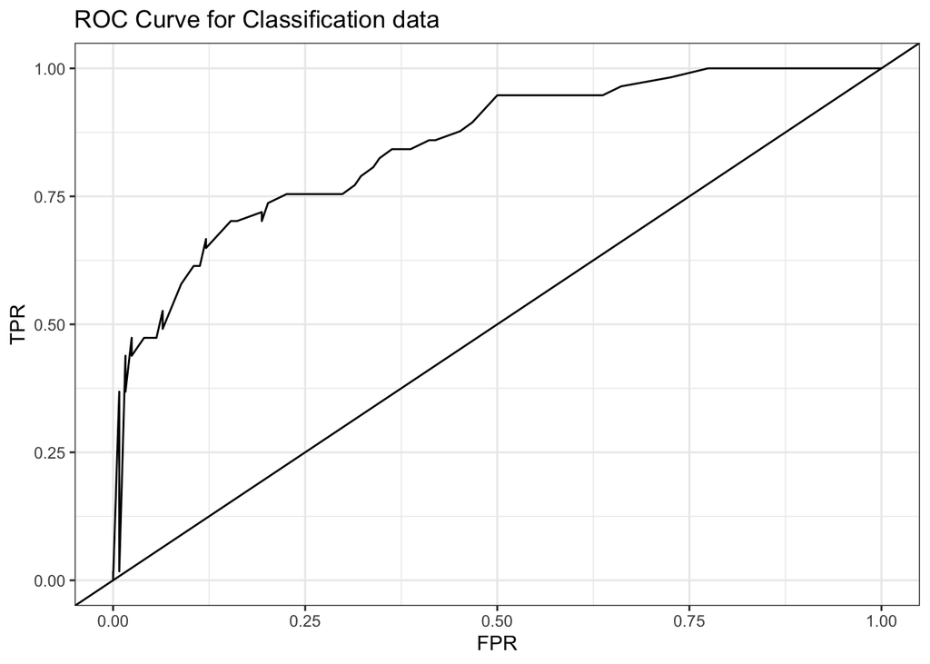

```r
roc_plot <- function(df, probability) {
  set.seed(824)

  x <- seq(0, 1, .01)
  FPR <- numeric(length(x))
  TPR <- FPR
  pos <- sum(df$class == 1)
  neg <- sum(df$class == 0)

  for (i in 1:length(x)) {
    data_subset <- subset(df, df$scored.probability <= x[i])

    # true positive
    TP <- sum(data_subset[data_subset$class == 1, probability] > 0.5)

    # true negative
    TN <- sum(data_subset[data_subset$class == 0, probability] <= 0.5)

    # false positive
    FP <- sum(data_subset[data_subset$class == 0, probability] > 0.5)

    # false negative
    FN <- sum(data_subset[data_subset$class == 1, probability] <= 0.5)

    TPR[i] <- 1 - (TP + FN) / pos
    FPR[i] <- 1 - (TN + FP) / neg
  }

  classification_data <- data.frame(TPR, FPR)


  ggplot <- ggplot(classification_data, aes(FPR, TPR))

  plot = ggplot +
    geom_line() +
    geom_abline(intercept = 0) +
    ggtitle("ROC Curve for Classification data") +
    theme_bw()

  height = (classification_data$TPR[-1] +
            classification_data$TPR[-length(classification_data$TPR)]) / 2
  width = -diff(classification_data$FPR)
  AUC = sum(height * width)

  return (list(AUC = AUC, plot))
}

roc_plot(df, "scored.probability")
```

## 11. Use All Functions

```r
Accuracy <- accuracy(df)
Error <- error(df)
Precision <- precision(df)
Sensitivity <- sensitivity(df)
Specificity <- specificity(df)
F1_score <- f1_score(df)
ROC <- roc_plot(df, "scored.probability")
AUC <- ROC$AUC

classification_data <- t(data.frame(Accuracy,
                                    Error,
                                    Precision,
                                    Sensitivity,
                                    Specificity,
                                    F1_score,
                                    AUC))
classification_data
```

```
##                  [,1]
## Accuracy    0.8066298
## Error       0.1933702
## Precision   0.8437500
## Sensitivity 0.4736842
## Specificity 0.9596774
## F1_score    0.6067416
## AUC         0.8488964
```

## 12. Compare to caret Functions

```r
cm <- confusionMatrix(data = as.factor(df$scored.class),
                      reference = as.factor(df$class),
                      positive = "1")
cm
```

```
## Confusion Matrix and Statistics
##
##           Reference
## Prediction   0   1
##          0 119  30
##          1   5  27
##
##                Accuracy : 0.8066
##                  95% CI : (0.7415, 0.8615)
##     No Information Rate : 0.6851
##     P-Value [Acc > NIR] : 0.0001712
##
##                   Kappa : 0.4916
##
##  Mcnemar's Test P-Value : 4.976e-05
##
##             Sensitivity : 0.4737
##             Specificity : 0.9597
##          Pos Pred Value : 0.8438
##          Neg Pred Value : 0.7987
##              Prevalence : 0.3149
##          Detection Rate : 0.1492
##    Detection Prevalence : 0.1768
##       Balanced Accuracy : 0.7167
##
##        'Positive' Class : 1
##
```

```r
Sensitivity == cm$byClass["Sensitivity"]
```

```
## Sensitivity
##        TRUE
```

```r
Specificity == cm$byClass["Specificity"]
```

```
## Specificity
##        TRUE
```

```r
Accuracy == cm$overall["Accuracy"]
```

```
## Accuracy
##     TRUE
```

Our homebrew R functions match with the caret() package functions.

## 13. pROC

```r
roc <- roc(df$class, df$scored.probability)
```

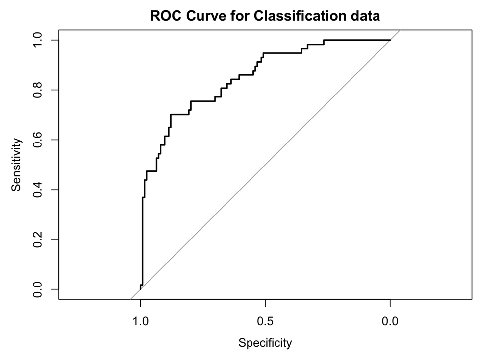

```r
plot(roc, main="ROC Curve for Classification data")
```

```r
# area under curve
roc$auc
```

```
## Area under the curve: 0.8503
```

## References

1. Kuhn and Johnson. Applied Predictive Modeling.
2. Web tutorials: http://www.saedsayad.com/model_evaluation_c.htm